# my_project

Marcin Solnicki

2022-12-15

## Short Description

London bike sharing project- the purpose to predict future bike shares.

The project consist of two elements: -exploratory data analysis -advanced analyst

Dataset downloaded from Kaggle [London bike sharing dataset | Kaggle](https://www.kaggle.com/datasets/hmavrodiev/london-bike-sharing-dataset?datasetId=376751&language=R)

```r
library(lattice)
library(dplyr)
```

```r
library(ggplot2)
df<-read.csv("C:/Users/soma2003/Desktop/bike_share.csv", header = TRUE, sep = ",")
head(df)
```

```
##             timestamp cnt  t1  t2   hum wind_speed weather_code is_holiday
## 1 2015-01-04 00:00:00 182 3.0 2.0  93.0        6.0            3          0
## 2 2015-01-04 01:00:00 138 3.0 2.5  93.0        5.0            1          0
## 3 2015-01-04 02:00:00 134 2.5 2.5  96.5        0.0            1          0
## 4 2015-01-04 03:00:00  72 2.0 2.0 100.0        0.0            1          0
## 5 2015-01-04 04:00:00  47 2.0 0.0  93.0        6.5            1          0
## 6 2015-01-04 05:00:00  46 2.0 2.0  93.0        4.0            1          0
##   is_weekend season
## 1          1      3
## 2          1      3
## 3          1      3
## 4          1      3
## 5          1      3
## 6          1      3
```

remove unnecessary variable:

```r
df <- subset(df, select = -weather_code)
head(df)
```

```
##             timestamp cnt  t1  t2   hum wind_speed is_holiday is_weekend season
## 1 2015-01-04 00:00:00 182 3.0 2.0  93.0        6.0          0          1      3
## 2 2015-01-04 01:00:00 138 3.0 2.5  93.0        5.0          0          1      3
## 3 2015-01-04 02:00:00 134 2.5 2.5  96.5        0.0          0          1      3
## 4 2015-01-04 03:00:00  72 2.0 2.0 100.0        0.0          0          1      3
## 5 2015-01-04 04:00:00  47 2.0 0.0  93.0        6.5          0          1      3
## 6 2015-01-04 05:00:00  46 2.0 2.0  93.0        4.0          0          1      3
```

Variables:

- “timestamp” - timestamp field for grouping the data “cnt” - the count of a new bike shares
- “t1” - real temperature in C
- “t2” - temperature in C “feels like” “wind_speed”-speed of wind
- “hum” - humidity in percentage “windspeed” - wind speed in km/h
- “isholiday” - boolean field - 1 holiday / 0 non holiday
- “isweekend” - boolean field - 1 if the day is weekend
- “season” - category field meteorological seasons: 0-spring ; 1-summer; 2-fall; 3-winter.

#extracting year and month from date

```r
df$year<-format(as.Date(df$timestamp, format="%Y-%m-%d"), "%Y")
 df$month<-format(as.Date(df$timestamp, format="%Y-%m-%d"), "%m")
tail(df)
```

```
##                 timestamp  cnt  t1  t2  hum wind_speed is_holiday is_weekend
## 17409 2017-01-03 18:00:00 2220 5.0 1.0 81.0         22          0          0
## 17410 2017-01-03 19:00:00 1042 5.0 1.0 81.0         19          0          0
## 17411 2017-01-03 20:00:00  541 5.0 1.0 81.0         21          0          0
## 17412 2017-01-03 21:00:00  337 5.5 1.5 78.5         24          0          0
## 17413 2017-01-03 22:00:00  224 5.5 1.5 76.0         23          0          0
## 17414 2017-01-03 23:00:00  139 5.0 1.0 76.0         22          0          0
##       season year month
## 17409      3 2017    01
## 17410      3 2017    01
## 17411      3 2017    01
## 17412      3 2017    01
## 17413      3 2017    01
## 17414      3 2017    01
```

time frame 2015/01/04- 2017/01/03

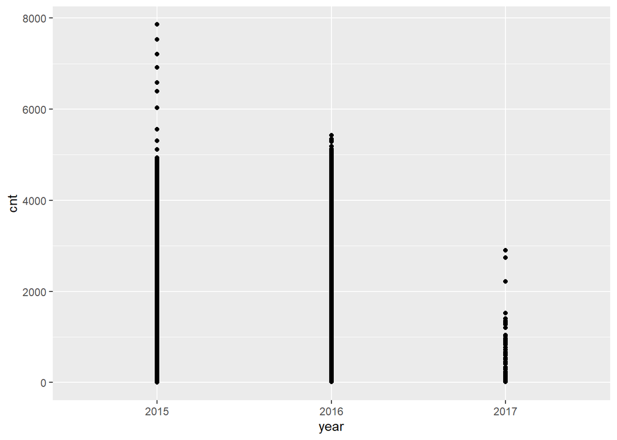

```r
ggplot(df,aes(x=year,y=cnt))+geom_point()
```

Filtering out 2017 from dataset

```r
df<-df%>% filter(year!=2017)
table(df$year)
```

```
##
## 2015 2016
## 8643 8699
```

## Histograms

```r
par(mfrow=c(2,2))
options(repr.plot.width=12, repr.plot.height=7)
hist(df$cnt, main="Rentals",xlab="rentals");hist
```

```
## function (x, ...)
## UseMethod("hist")
## <bytecode: 0x0000000013afdc48>
## <environment: namespace:graphics>
```

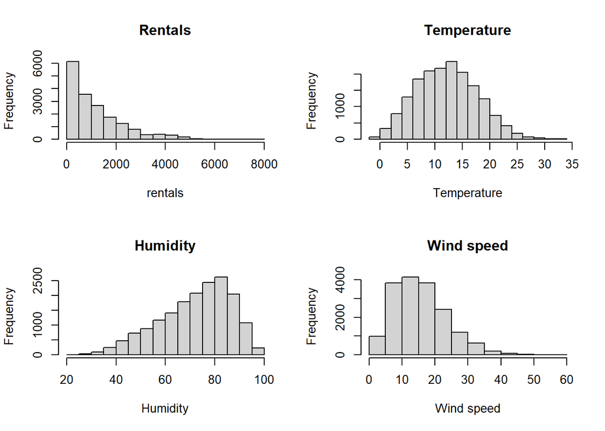

```r
hist(df$t1, main = "Temperature", xlab = "Temperature");
hist(df$hum, main = "Humidity",xlab = "Humidity");
hist(df$wind_speed, main = "Wind speed", xlab = "Wind speed");
```

```r
par(mfrow=c(1,1))
```

Average Rentals by month

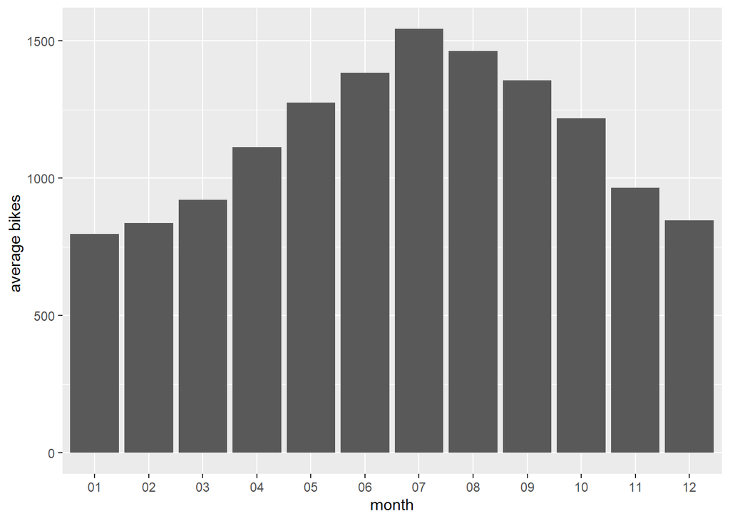

```r
avg_cnt_m <- df %>% group_by(month) %>% summarise(avg_cnt = mean(cnt))
ggplot(avg_cnt_m)+geom_col(aes(x=month,y=avg_cnt))+ylab('average bikes ')
```

Summary of whole data

```r
summary(df)
```

```
##   timestamp              cnt             t1             t2
##  Length:17342       Min.   :   0   Min.   :-1.5   Min.   :-6.00
##  Class :character   1st Qu.: 260   1st Qu.: 8.5   1st Qu.: 6.00
##  Mode  :character   Median : 846   Median :12.5   Median :12.50
##                     Mean   :1146   Mean   :12.5   Mean   :11.56
##                     3rd Qu.:1676   3rd Qu.:16.0   3rd Qu.:16.00
##                     Max.   :7860   Max.   :34.0   Max.   :34.00
##       hum           wind_speed      is_holiday        is_weekend
##  Min.   : 20.50   Min.   : 0.00   Min.   :0.00000   Min.   :0.0000
##  1st Qu.: 63.00   1st Qu.:10.00   1st Qu.:0.00000   1st Qu.:0.0000
##  Median : 74.50   Median :15.00   Median :0.00000   Median :0.0000
##  Mean   : 72.28   Mean   :15.92   Mean   :0.02076   Mean   :0.2852
##  3rd Qu.: 83.00   3rd Qu.:20.50   3rd Qu.:0.00000   3rd Qu.:1.0000
##  Max.   :100.00   Max.   :56.50   Max.   :1.00000   Max.   :1.0000
##      season          year              month
##  Min.   :0.000   Length:17342       Length:17342
##  1st Qu.:0.000   Class :character   Class :character
##  Median :1.000   Mode  :character   Mode  :character
##  Mean   :1.486
##  3rd Qu.:2.000
##  Max.   :3.000
```

Rentals By Season:

0-spring,1-summer,2-autumn,3-winter

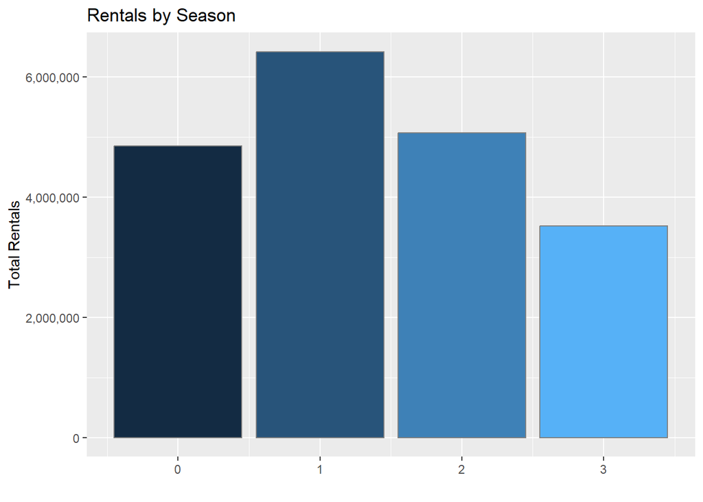

```r
s = c("olivedrab3", 'yellow', 'orange', 'grey50')
options(repr.plot.width=10, repr.plot.height=8)
df %>% group_by(season) %>%
  summarise(n = n(), rent = sum(cnt)) %>%
  ggplot(aes(season, rent, fill = season)) +
  geom_bar(stat = "identity", show.legend = F, color = 'gray50') +
  labs(title = "Rentals by Season", x = "", y = "Total Rentals") +
 scale_y_continuous(labels = scales::label_comma())
```

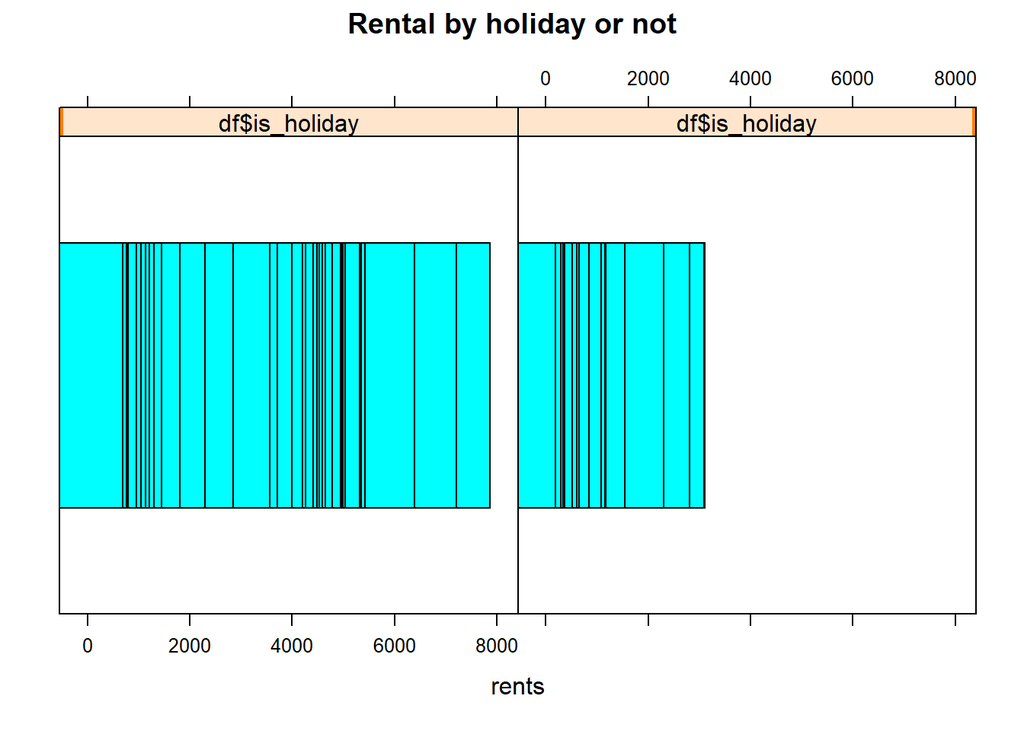

```r
barchart(~df$cnt|df$is_holiday,main="Rental by holiday or not", xlab="rents")
```

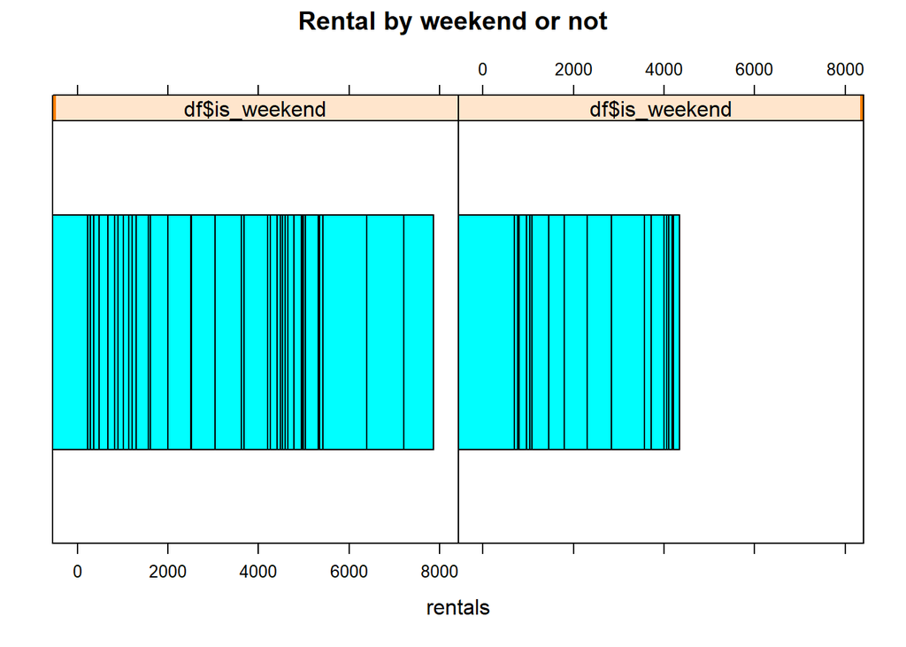

```r
barchart(~df$cnt|df$is_weekend,main="Rental by weekend or not",xlab="rentals")
```

Density plot of real temperature grouped by season

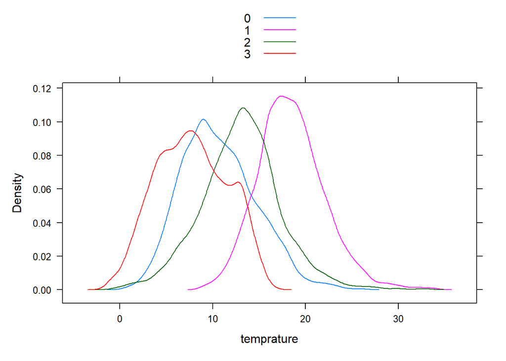

```r
densityplot(~t1, xlab="temprature", data=df, groups=season,
plot.points=FALSE, auto.key = TRUE)
```

## Correlation matrix

```r
num_d<-select_if(df,is.numeric)
corr<-round(cor(num_d),2)
corr
```

```
##              cnt    t1    t2   hum wind_speed is_holiday is_weekend season
## cnt         1.00  0.39  0.37 -0.46       0.12      -0.05      -0.10  -0.11
## t1          0.39  1.00  0.99 -0.45       0.15      -0.03      -0.01  -0.28
## t2          0.37  0.99  1.00 -0.40       0.09      -0.03      -0.01  -0.28
## hum        -0.46 -0.45 -0.40  1.00      -0.29       0.03       0.03   0.29
## wind_speed  0.12  0.15  0.09 -0.29       1.00       0.00       0.01   0.01
## is_holiday -0.05 -0.03 -0.03  0.03       0.00       1.00      -0.09  -0.05
## is_weekend -0.10 -0.01 -0.01  0.03       0.01      -0.09       1.00   0.00
## season     -0.11 -0.28 -0.28  0.29       0.01      -0.05       0.00   1.00
```

Rentals to humidity(cor=-0.46)

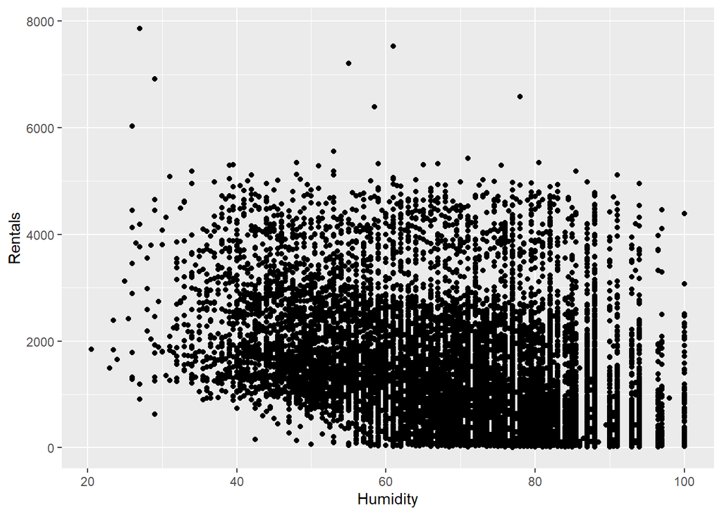

```r
ggplot(df,aes(hum,cnt))+geom_point()+ylab("Rentals")+xlab("Humidity")
```

The higher humidity, the less amount of rented bikes. Correlation minus

Cleaning outliers

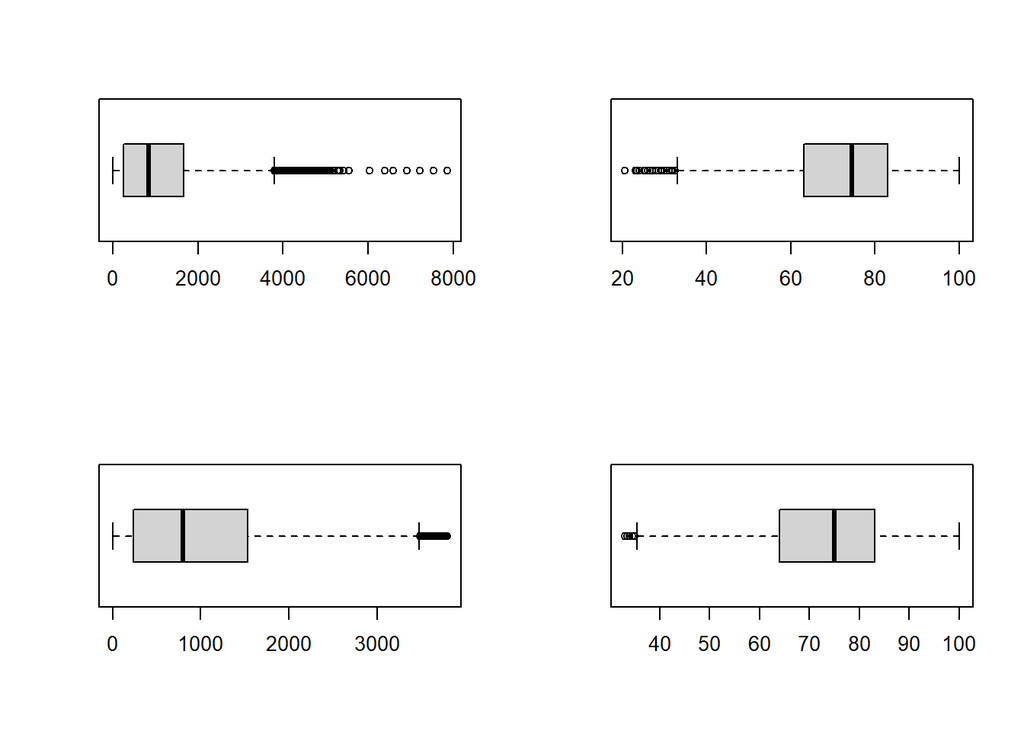

```r
par(mfrow=c(2,2))
boxplot(df$cnt,horizontal = TRUE)
boxplot(df$hum,horizontal = TRUE)
outlh<-boxplot.stats(df$hum)$out
outlc<-boxplot.stats(df$cnt)$out
#outl
df<-df%>%filter(!between(hum,min(outlh),max(outlh)))
df<-df%>%filter(!between(cnt,min(outlc),max(outlc)))
##without outliers
boxplot(df$cnt,horizontal = TRUE)
boxplot(df$hum,horizontal = TRUE)
```

## linear regression

Model summary

```r
lm1<-lm(formula = cnt~hum,data=df)
summary(lm1)
```

```
##
## Call:
## lm(formula = cnt ~ hum, data = df)
##
## Residuals:
##     Min      1Q  Median      3Q     Max
## -1800.6  -533.4  -192.8   346.4  3436.9
##
## Coefficients:
##              Estimate Std. Error t value Pr(>|t|)
## (Intercept) 3283.6231    32.0675  102.40   <2e-16 ***
## hum          -31.1768     0.4326  -72.06   <2e-16 ***
## ---
## Signif. codes:  0 '***' 0.001 '**' 0.01 '*' 0.05 '.' 0.1 ' ' 1
##
## Residual standard error: 775.4 on 16617 degrees of freedom
## Multiple R-squared:  0.2381, Adjusted R-squared:  0.238
## F-statistic:  5193 on 1 and 16617 DF,  p-value: < 2.2e-16
```

Model diagnostic

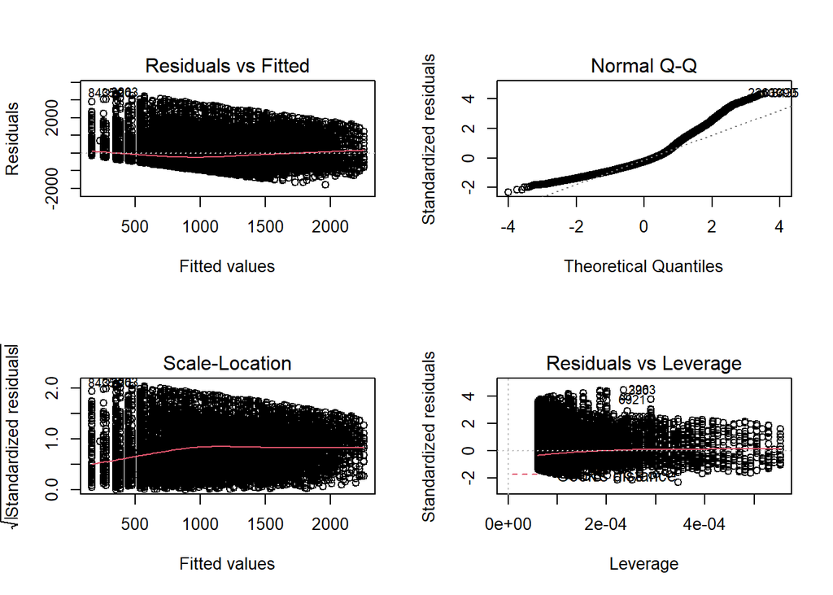

```r
options(repr.plot.width = 14,repr.plot.height = 10)
par(mfrow= c(2,2))
plot(lm1)
```

Theoretical (model) vs real values

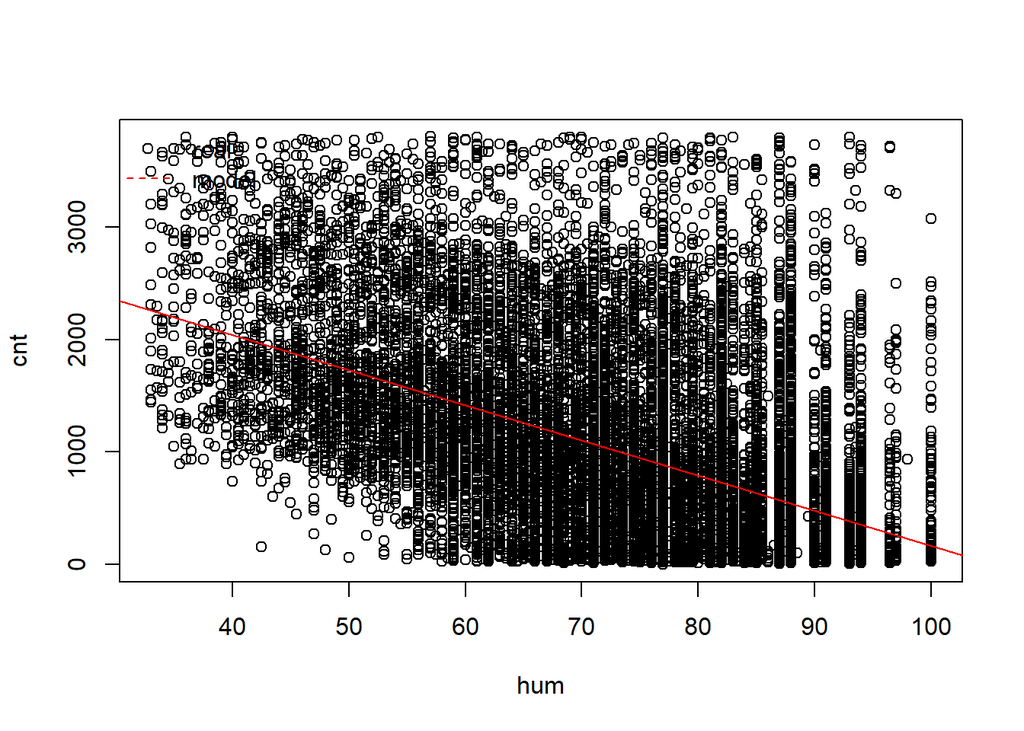

```r
par(mfrow=c(1,1))
plot(df$cnt~df$hum, xlab="hum", ylab="cnt")
abline(lm1, col='red')
legend("topleft", legend=c("real","model"), col=c("black","red"), pch=c(1,NA), lty=c(NA,2), bty="n")
```

Residuals analysis

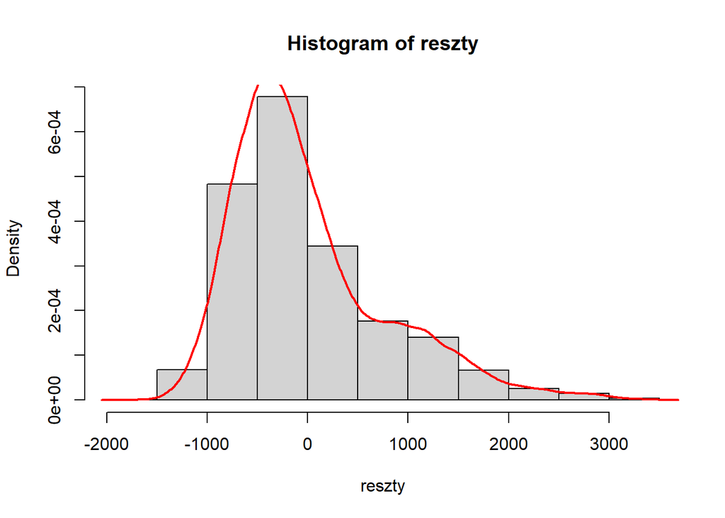

```r
reszty = residuals(lm1)
hist(reszty, prob=TRUE)
lines(density(reszty), col="red", lwd=2)
```